11.09.2021

# Generating words with an RNN in TensorFlow

Imagine yourself in the context of reading a book. If we read sentence for sentence, a topic which is explained gets more clear. We hold the informations about the read sentences in our memory and later we are able to connect this sentences with the new words which we read to understand the context. That is similar to what an RNN is doing. An RNN has memorized objects from the past and can learn so about the next word: "Moscow is the capital city of ...?" - Russia, right!

```python
from tensorflow.keras.preprocessing.sequence import pad_sequences
from tensorflow.keras.layers import Embedding, LSTM, Dense, Dropout, Bidirectional
from tensorflow.keras.preprocessing.text import Tokenizer
from tensorflow.keras.models import Sequential
from tensorflow.keras.optimizers import Adam
from tensorflow.keras import regularizers
import tensorflow.keras.utils as ku
import numpy as np
```

First of all we have to import everything what we need.

```python
from google.colab import drive
drive.mount('/content/drive')
```

If you work with Google Colab, a way for working with files is loading them into your drive and then access them from there. We train our model on text of William Shakespeare.

```python
tokenizer = Tokenizer() #tokenizer encodes a word into an numerical value

data = open('/content/drive/MyDrive/Projects/Tensorflow Certificate/Prep/sonnets.txt').read() #read text file
corpus = data.lower().split("\n") #put every newline in a list
tokenizer.fit_on_texts(corpus) #apply tokenizer for encoding every word into numerical value
total_words = len(tokenizer.word_index) + 1 #word_index creates a dictionary with every word and the associated numerical value - total_words is the length of words of the index

input_sequences = [] #empty list for sequences
for line in corpus: #for every line in the file
	token_list = tokenizer.texts_to_sequences([line])[0] #every line is transformed into a sequence "[4,5,13,4,5,9]" - its the numerical value from every word on a line in a list
	for i in range(1, len(token_list)): #iteration till the length of token_list
		n_gram_sequence = token_list[:i+1]
		input_sequences.append(n_gram_sequence)
```

```python
max_sequence_len = max([len(x) for x in input_sequences]) #finds the longest sequence
input_sequences = np.array(pad_sequences(input_sequences, maxlen=max_sequence_len, padding='pre')) #define padding
```

Padding is useful to have the same length of all sequences. For example is it possible that without padding sequences are from different length like [3,4,6,7] is different to [2,4]. In that case padding helps to fill the sequence with additional inputs. For our example this would be [3,4,6,7] and [0,0,2,4].

```python
#create predictors and label
predictors, label = input_sequences[:,:-1],input_sequences[:,-1]
label = ku.to_categorical(label, num_classes=total_words)
print(label)
```

```
[[0. 0. 0. ... 0. 0. 0.]
 [0. 0. 0. ... 0. 0. 0.]
 [0. 0. 0. ... 0. 0. 0.]
 ...
 [0. 0. 0. ... 0. 0. 1.]
 [0. 0. 0. ... 0. 0. 0.]
 [0. 0. 0. ... 0. 0. 0.]]
```

Creating the model

```python
model = Sequential() #on Sequential() we stack all the layers
model.add(Embedding(total_words, 100, input_length=max_sequence_len-1)) #Embedding layer transforms inputs into vectors to predict similarities
model.add(Bidirectional(LSTM(150, return_sequences = True))) #LSTM Layer (long short term memory) - special form of an RNN
model.add(Dropout(0.2)) #a dropout is a technique which is used to minimize overfitting - in this case 20% of the neurons of the layer are removed
model.add(LSTM(100)) #another LSTM Layer
model.add(Dense(total_words/2, activation='relu', kernel_regularizer=regularizers.l2(0.01))) #a Dense Layer including regularizers - the regularizers are used to control the coefficients of the weights
model.add(Dense(total_words, activation='softmax')) #one word of all the input words has the highest probability to be the next word because of that we use a softmax

model.compile(loss='categorical_crossentropy', optimizer='adam', metrics=['accuracy']) #defining loss and optimizer and built the model on it with compile


print(model.summary())
```

```
Model: "sequential"
_________________________________________________________________
Layer (type)                 Output Shape              Param #
=================================================================
embedding (Embedding)        (None, 10, 100)           321100
_________________________________________________________________
bidirectional (Bidirectional (None, 10, 300)           301200
_________________________________________________________________
dropout (Dropout)            (None, 10, 300)           0
_________________________________________________________________
lstm_1 (LSTM)                (None, 100)               160400
_________________________________________________________________
dense (Dense)                (None, 1605)              162105
_________________________________________________________________
dense_1 (Dense)              (None, 3211)              5156866
=================================================================
Total params: 6,101,671
Trainable params: 6,101,671
Non-trainable params: 0
_________________________________________________________________
None
```

The Embedding layer transforms inputs into vectors. The aim of this vectors is to know how similar the inputs are. For example if you have an corpus on words of countries and capital cities then with the input of Russia the the most similar vector would be Moscow.

```python
history = model.fit(predictors, label, epochs=100, verbose=1) #train the model
```

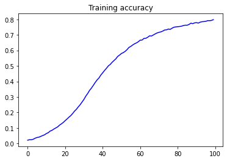

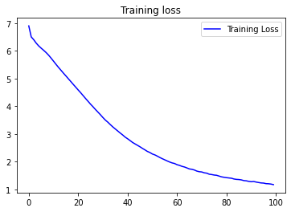

```python
import matplotlib.pyplot as plt #importing additionally matlplotlib for displaying the results of our model accuracy and loss
acc = history.history['accuracy']
loss = history.history['loss']

epochs = range(len(acc))

plt.plot(epochs, acc, 'b', label='Training accuracy')
plt.title('Training accuracy')

plt.figure()

plt.plot(epochs, loss, 'b', label='Training Loss')
plt.title('Training loss')
plt.legend()

plt.show()
```

```python
seed_text = "Help me artificial intelligence, you're my only hope" #on this text we start with generating next words
next_words = 100 #the number of next words we wanna generate

for _ in range(next_words):
	token_list = tokenizer.texts_to_sequences([seed_text])[0] #applying tokenizer on seed_text so we get the seed_text in form of sequences and taking the index 0 sequence
	token_list = pad_sequences([token_list], maxlen=max_sequence_len-1, padding='pre') #applying padding on the sequence
	predicted = model.predict_classes(token_list, verbose=0)
	output_word = ""
	for word, index in tokenizer.word_index.items():
		if index == predicted:
			output_word = word
			break
	seed_text += " " + output_word #adds every time if a new word gets predict the word to the seed text
print(seed_text)
```

```
Help me artificial intelligence, you're my only hope are such play no horse still 'tis on trust view skill ' back back back back dyed back proceeds free forth men's bright days held hate dearer hate staineth hate tell ' back back swear thee from good clearer worth away weeds weeds crime weeds weeds …
```

Finally we created an text with additional 100 new generated words. The quality is not high but it is so much space for improvement!

Max Hager